# Homework two

Adrian Harris

12/01/2019

Loading libraries

```r
library(readr)
library(dplyr)
```

```r
library(tidyr)
library(ggplot2)
library(wesanderson)
```

Loading data set and uncounting the Frequency

```r
college  <- read.csv("http://vicpena.github.io/admin.csv", header=TRUE)
college2 = college %>% uncount(Freq)
```

### College admissions dataset

Question One

More men get admitted

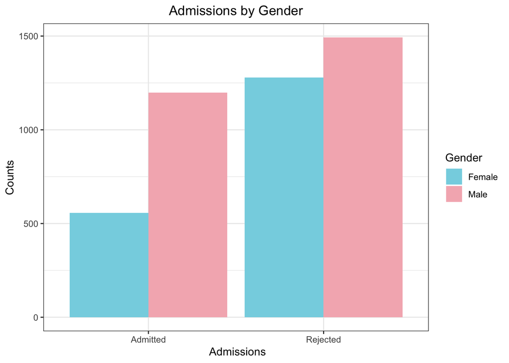

```r
ggplot(college2) +
  aes(x = Admit, fill = Gender)+
  xlab(" Admissions")+
  ylab("Counts")+
  theme_bw()+
  ggtitle("Admissions by Gender")+
  geom_bar(position = "dodge")+
  theme(plot.title = element_text(hjust = 0.5))+
  scale_fill_manual(values = wes_palette("Moonrise3", n = 5))
```

Question Two

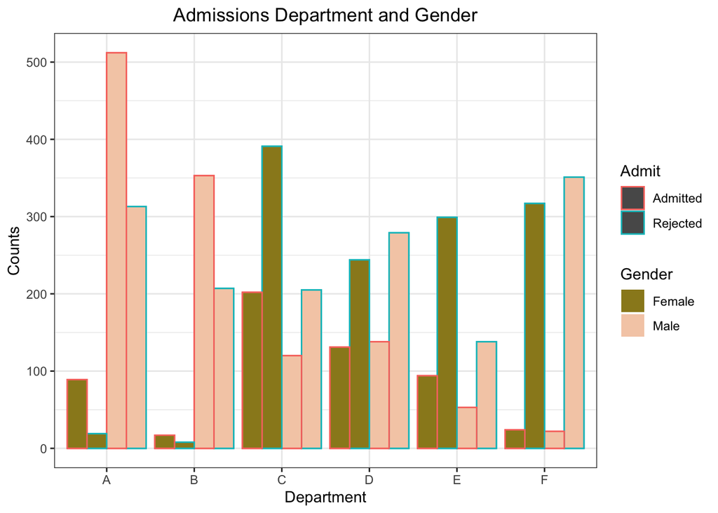

```r
ggplot(college2) +
  aes(x = Dept, fill = Gender,
      color = Admit) +
  geom_bar(position = "dodge")+
  xlab("Department")+
  ylab("Counts")+
  theme_bw()+
  ggtitle("Admissions Department and Gender")+
  geom_bar(position = "dodge")+
  theme(plot.title = element_text(hjust = 0.5))+
  scale_fill_manual(values = wes_palette("Royal2", n = 5))
```

### Conclusion

I see that more males are getting accepted into college. The number is about double the females. Moving to the next plot, looking at each department, it is almost male-dominated again. In some departments, the number of females outweighs the males but the males are not so far behind.

### Salaries and anxiety

```r
anx = read.csv("http://vicpena.github.io/sta9750/salary.csv", header=TRUE)
```

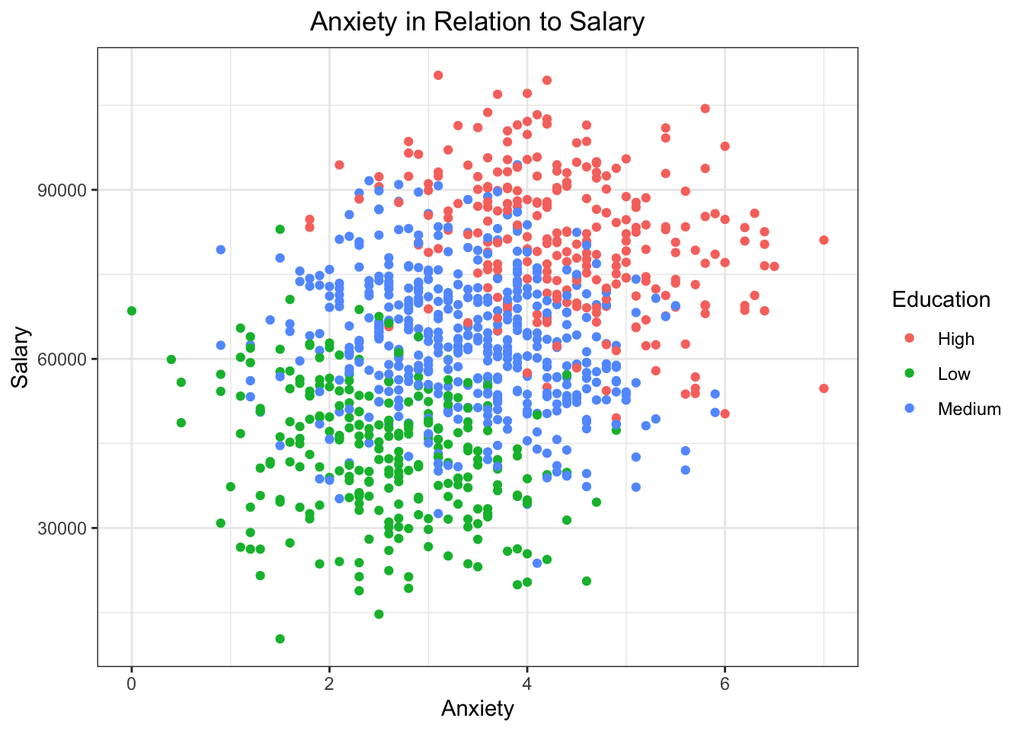

```r
ggplot(anx)+
  aes(x = Anxiety, y = Salary,
      color = Education)+
  geom_point()+
  theme_bw()+
  ggtitle("Anxiety in Relation to Salary")+
  theme(plot.title = element_text(hjust = 0.5))+
  scale_fill_manual(values = wes_palette("Moonrise3", n = 5))
```

I would say yes that the higher paying job you have the more stress that you will have. The correlation between them is not a very strong one. Just by estimating, I would say it is positively correlated between 6.and .7. I say this because you see that there are some high paying jobs that have a lower stress level (below two) and there are low paying jobs that have almost a 5 stress level.

#### Call center

Question one

```r
busycalls = rep(200, 6)
regcalls = rep(60, 6)
nsim = 1e5
```

```r
lambda = 5*sum(busycalls)
```

```r
week_of_busy_calls = rpois(nsim, lambda = lambda)
```

Expected number of calls

```r
mean(week_of_busy_calls)
```

```
## [1] 6000.193
```

Question two

```r
200/30
```

```
## [1] 6.666667
```

they should have about 7 operators per hour to handle the busy days

Question three

Took the weighted average to factor in the the probability of it being a busy day or regualar day

```r
ll = (.8*sum(regcalls) + .2*sum(busycalls))
```

Simualtion

```r
sim = rpois(nsim, lambda = ll)
```

Average number of calls they get in a day

```r
mean(sim)
```

```
## [1] 528.0462
```

Question Four

If you are during it on the number of operators, you need per hour and they work right though the day you would need about 4 operators per hour. I say this because when I simulated the weighted average of number of calls during the day you get a mean of 528 and the highest value of simulated trials amounted to around 600 calls per day. So, then I took 600 and divided it by 6 because of it being a six-hour work day. That gave about 100 calls per hour and then I divided that number by 30 to get how many operators you would need in that given hour. I would pick the weighted average because if you choose either the busy or regular day you might have idle capacity or your workers are fully utilized and still not meeting the demand of the calls.

Question five

```r
number_of_calls_december_avg = (31*(.8*sum(regcalls) + .2*sum(busycalls)))
sim2 = rpois(nsim, lambda = number_of_calls_december_avg)
```

Average number would be 16368 calls in December

```r
mean(sim2)
```

```
## [1] 16368.58
```

Restaurant

Question One

```r
weeklycost = 2500+4500+4500+2500
```

```r
prob_of_money = pnorm(weeklycost,
      mean = 5*2000+3000*2,
      sd = sqrt(5*500^2+2*700^2),
      lower.tail = FALSE)
```

Majority of the time they are making money

```r
prob_of_money
```

```
## [1] 0.9097633
```

```r
moneysim = rpois(nsim, prob_of_money)
```

```r
table(moneysim)
```

```
## moneysim
##     0     1     2     3     4     5     6     7
## 40335 36699 16569  5088  1062   208    36     3
```

Question Two

```r
dailycosts = weeklycost/7
monthlycost= 31*dailycosts
```

```r
dec_lost_money = pnorm(monthlycost,
      mean = 3000*9+22*2000 ,
      sd = sqrt((31-9)*500^2+9*700^2),
      lower.tail = FALSE)
```

Agian most of the time they are making money

```r
dec_lost_money
```

```
## [1] 0.9978747
```

```r
decmoneysim = rpois(nsim, dec_lost_money)
```

```r
table(decmoneysim)
```

```
## decmoneysim
##     0     1     2     3     4     5     6     7
## 36855 36946 18114  6228  1489   307    57     4
```

Question Three

```r
yearlycosts = weeklycost*52
expyearlysales = (5*2000+2*3000)*52
```

```r
exceptedprofit = expyearlysales-yearlycosts
```

```r
yearmoneysim = rpois(nsim, exceptedprofit)
```

```r
mean(yearmoneysim)
```

```
## [1] 104002.4
```

```r
max(yearmoneysim)
```

```
## [1] 105401
```

```r
min(yearmoneysim)
```

```
## [1] 102627
```

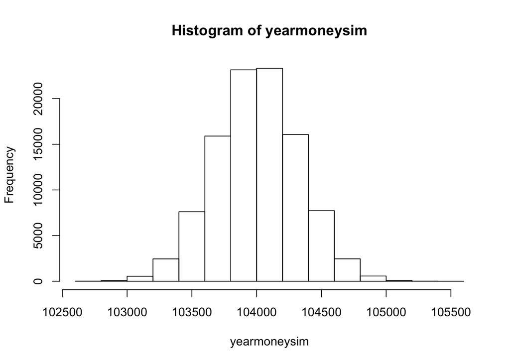

```r
hist(yearmoneysim)
```

Question Four

```r
costwithmark = weeklycost + 10000
prob_of_success = .8
prob_of_fail = .2
weeklyincrease = 1.15
```

Probalitiy that they are making money is very small

```r
p = pnorm(costwithmark,
          mean = 5*(2000*(1.15))+(3000*(1.15))*2,
          sd = sqrt(5*500^2+2*700^2),
          lower.tail = F)
```

```r
p
```

```
## [1] 8.840411e-05
```

```r
p2 = pnorm(costwithmark,
          mean = 5*2000+3000*2,
          sd = sqrt(5*500^2+2*700^2),
          lower.tail = F)
```

This shows if the sales don’t increase and the cost of the marketing is still incurred the probalitiy that they are making money is even *smaller*

```r
p2
```

```
## [1] 4.226165e-08
```

I wouldn’t run the marketing campaign because the probablitily that you make money is very small